# Batch67_3060_Tarun_Rastogi_PHD_EDA-Part-1

## Problem Statement

A hedge fund uses 6 financial factors to predict the alpha signal in a stock. This alpha signal is used to make purchase decisions about the stock. The hedge fund now collected and tagged microblogging data for sentiment from the Social Media platform called ‘StockTwits’. The hedge fund has anonymyzed the data, which contains 7 stock factors and an alpha signal. This alpha signal is generated using a near perfect algorithmic trading strategy. Unfortunately, the number of stock factors, collected to run that strategy, are extremely high and have to be collected from a large number of data vendors at a high price.

## Business understanding

A hedge fund's purpose is to maximize investor returns and eliminate risk. When deciding the value of a company, it's important to follow the news. For example, a product recall or natural disaster in a company's product chain. You want to be able to turn this information into a signal. Currently, the number of stock factors, collected to run that strategy, are extremely high and have to be collected from a large number of data vendors at a high price. If we use social networking plateform to understand the more about hedge funds and apply strategy to predict the alpha value along with stock factors , can reduce the expanse ratio of the company.

## Proposed solution

- Perform EDA on JSON data to get more insight about the stock twots
- Perform text sentiments Analysis on stock twits
- Apply Deep neural network and ML learaning both to get best sentiment score of tweets and choose best one
- Merge Json data with hedge fund csv
- Apply ML Algorithm to predict the alpha value

## Comparison Matrix

- Highest Accuracy in Text sentiment Analysis, we have got in logistic regession 81, also get more accurate result in Deep neural network(RNN) is 80.2

```python
#1)text sentiment Analysis on Stock Twits --

#  Sr No.      Algorithm                                    Accuracy on Train      Accuracy on validation

#   1         naive bayes Classifier                           80                       79
#   2         XGBoost Classifier                               82                       80
#   3         Random Forest Classifier                         65                       63
#   4         Logistic regression                              86                       81
#   5         Embedding_LSTM_NN                                80.4                    80.2
```

- Highest Macro Avg after apply many classifier ML algoritm , I got 67 from Random forest classifier

```python
#2) Alpha value prediction using below algorith--
#  Sr No.      Algorithm                                    Macro Avg on Train      Macro on validation

#   1         XGBoost Classifier                               72                       65
#   2         Random Forest Classifier                         70                       67
#   3         Logistic regression                              33                       33
#   4         Random Forest after Smoting                      67                       62
#   5         XGBoost Classifier after smoting                 52                       53
#   6         SVC Classifier                                   90                       34
```

## Load Libraries

```python
import pandas as pd
import numpy as np
import time
from scipy import stats
import seaborn as sns
import datetime as dt
import nltk
from nltk import word_tokenize,sent_tokenize
from nltk.tokenize import RegexpTokenizer, sent_tokenize
from nltk.stem import PorterStemmer,WordNetLemmatizer
from pandas.io.json import json_normalize
import matplotlib.pyplot as plt
%matplotlib inline
import seaborn as sns
from sklearn.model_selection import train_test_split
from keras.models import Sequential, Model
from keras.layers import Dense, Activation, Embedding, concatenate, Flatten, Input
from keras.preprocessing.text import Tokenizer
from keras.preprocessing.sequence import pad_sequences
from keras.utils import to_categorical
from keras.layers import Dense, Input, GlobalMaxPooling1D
from keras.layers import Conv1D, MaxPooling1D, Embedding
from keras.models import Model
from keras.layers import Dropout
import unicodedata
import re
from sklearn.metrics import classification_report , f1_score
from sklearn.model_selection import GridSearchCV
import nltk
#nltk.download('punkt')
#nltk.download('wordnet')
from string import punctuation
from nltk.tokenize import word_tokenize
import swifter
```

## Read Train factor CSV file

```python
csv_train_data=pd.read_csv(r"C:\Users\F85TR00\Desktop\data_science\PHD_exam\train_factors-1573207730757.csv")
```

## Explore the CSV file

See 1'st 10 row of data  
CSV has 7 Stock Factor features ,date,ID and ticker features  
Alpha is Target Variable  
CSV has 27006 rows data and 11 columns  
Date is in object type, need to change type as Datetime  
Check how many unique tickers are avaible in train data

```python
csv_train_data.head(10)
```

|  | Id | date | ticker | SF1 | SF2 | SF3 | SF4 | SF5 | SF6 | SF7 | alpha |
| --- | --- | --- | --- | --- | --- | --- | --- | --- | --- | --- | --- |
| 0 | 1 | 21/08/18 | $NTAP | -0.628652 | 0.988891 | -0.055714 | 0.774379 | 0.551089 | -1.329229 | -0.995539 | 2 |
| 1 | 2 | 11/10/18 | $WYNN | 1.315786 | 1.438754 | 0.187327 | 0.608933 | -1.153030 | 1.859441 | 0.730995 | 3 |
| 2 | 3 | 21/08/18 | $DRI | -1.141388 | -1.455016 | 0.332755 | 0.674502 | 0.111326 | -0.478597 | -1.488157 | 1 |
| 3 | 4 | 10/07/18 | $ge | -0.054839 | -1.454149 | -0.162267 | -0.681870 | 0.307869 | -0.529987 | 0.404172 | 2 |
| 4 | 5 | 12/09/18 | $FE | -0.686366 | 0.838865 | 0.073830 | 0.679024 | 0.329463 | 1.262782 | -1.024042 | 2 |
| 5 | 6 | 16/09/18 | $F | 1.371319 | 0.288456 | -1.510710 | 1.887273 | 2.193964 | -1.266998 | 0.476990 | 1 |
| 6 | 7 | 25/09/18 | $LOW | 1.459736 | 0.268391 | -1.027821 | 0.229159 | 1.096598 | 1.363255 | 1.414198 | 1 |
| 7 | 8 | 27/07/18 | $ILMN | 0.381670 | 0.664366 | -0.333336 | -1.471580 | 0.317609 | 1.285183 | 1.303229 | 3 |
| 8 | 9 | 24/08/18 | $cmg | -1.189986 | 1.669897 | -0.561872 | 1.172239 | 1.912741 | -1.530536 | -1.584684 | 4 |
| 9 | 10 | 15/08/18 | $NEE | 0.166027 | -0.308584 | 0.210583 | -0.151859 | -0.523260 | -0.045953 | 0.178128 | 3 |

```python
#Describe the data
csv_train_data.describe()
```

|  | Id | SF1 | SF2 | SF3 | SF4 | SF5 | SF6 | SF7 | alpha |
| --- | --- | --- | --- | --- | --- | --- | --- | --- | --- |
| count | 27006.000000 | 27006.000000 | 27006.000000 | 27006.000000 | 27006.000000 | 27006.000000 | 27006.000000 | 27006.000000 | 27006.000000 |
| mean | 13503.500000 | 0.005429 | -0.001005 | -0.024421 | -0.042420 | 0.041465 | 0.002597 | 0.036744 | 2.379582 |
| std | 7796.105021 | 0.941853 | 0.996130 | 0.539555 | 1.111309 | 0.976028 | 0.998839 | 1.204473 | 1.008681 |
| min | 1.000000 | -4.114670 | -4.578587 | -2.609150 | -6.329798 | -5.480268 | -4.338751 | -5.347869 | 1.000000 |
| 25% | 6752.250000 | -0.596792 | -0.666310 | -0.300187 | -0.767247 | -0.518641 | -0.668027 | -0.688198 | 2.000000 |
| 50% | 13503.500000 | 0.012104 | -0.013257 | -0.040786 | -0.058629 | 0.072127 | 0.007417 | 0.081374 | 2.000000 |
| 75% | 20254.750000 | 0.611574 | 0.669094 | 0.241424 | 0.677433 | 0.616538 | 0.674592 | 0.807556 | 3.000000 |
| max | 27006.000000 | 4.415048 | 3.822270 | 3.452486 | 4.907407 | 4.779911 | 4.075428 | 5.182912 | 4.000000 |

```python
# Check the Shape of train data
csv_train_data.shape
```

```
(27006, 11)
```

```python
# Check data types of all variable in train data
csv_train_data.dtypes
```

```
Id          int64
date       object
ticker     object
SF1       float64
SF2       float64
SF3       float64
SF4       float64
SF5       float64
SF6       float64
SF7       float64
alpha       int64
dtype: object
```

```python
# Converting the Date to datetime format
csv_train_data.date = pd.to_datetime(csv_train_data.date)
csv_train_data.dtypes
```

```
Id                 int64
date      datetime64[ns]
ticker            object
SF1              float64
SF2              float64
SF3              float64
SF4              float64
SF5              float64
SF6              float64
SF7              float64
alpha              int64
dtype: object
```

```python
#Found that -Following Records has Tickers Starting with $$
print("Total ",len(csv_train_data[csv_train_data.ticker.str.startswith("$$")])," Tickers Starting with $$")
csv_train_data[csv_train_data.ticker.str.startswith("$$")]
```

```
Total  5  Tickers Starting with $$
```

|  | Id | date | ticker | SF1 | SF2 | SF3 | SF4 | SF5 | SF6 | SF7 | alpha |
| --- | --- | --- | --- | --- | --- | --- | --- | --- | --- | --- | --- |
| 12463 | 12464 | 2018-11-07 | $$DIS | -0.437284 | 1.234022 | -0.556197 | -0.722800 | 1.311736 | 2.195902 | 0.202720 | 2 |
| 15323 | 15324 | 2018-08-31 | $$aapl | -0.488066 | -2.076737 | -0.853467 | 0.237428 | 1.981247 | -0.428836 | -0.334862 | 4 |
| 15360 | 15361 | 2018-04-09 | $$NKE | 1.121419 | -1.881420 | -0.966242 | -2.036807 | 1.049094 | 0.775931 | 2.457866 | 2 |
| 16699 | 16700 | 2018-11-08 | $$s | 0.532435 | -0.844781 | 0.213112 | 1.880659 | -0.632535 | -1.547038 | -0.718908 | 4 |
| 25844 | 25845 | 2018-10-25 | $$amzn | 0.068119 | -0.905671 | -0.332764 | 0.164554 | 0.614646 | 0.801443 | 0.051487 | 1 |

```python
# Renaming Tickets where it starts with $$ instead of $
csv_train_data.ticker = csv_train_data.ticker.apply(lambda x: x.replace("$$","$"))
# Convering the Lowercase Tickers to Upper case to be consistent or Pandas with treat them unique
csv_train_data.ticker = csv_train_data.ticker.str.upper()
```

```python
# Check Tickers with $$ are renamed
print("Total ",len(csv_train_data[csv_train_data.ticker.str.startswith("$$")])," Tickers Starting with $$")
csv_train_data[csv_train_data.ticker.str.startswith("$$")]
```

```
Total  0  Tickers Starting with $$
```

|  | Id | date | ticker | SF1 | SF2 | SF3 | SF4 | SF5 | SF6 | SF7 | alpha |
| --- | --- | --- | --- | --- | --- | --- | --- | --- | --- | --- | --- |

```python
# Check how many unique tickers are avaible in train factor csv
len(csv_train_data.ticker.unique())
```

```
872
```

## See Target Variable -Alpha Distribution

# Observation :- Target Variable is not equally distributed, class weights need to take in consideration while predicting the Alpha value.

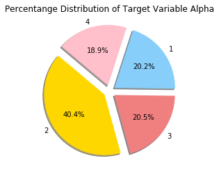

```python
alpha = csv_train_data.alpha.value_counts()
# Data to plot piechart
my_color = ['gold', 'lightcoral', 'lightskyblue', 'pink','yellowgreen']
explode = (0.1, 0.1, 0.1, 0.1)  # explode 1st slice

# Plot
plt.pie(list(alpha.values), explode=explode, labels=list(alpha.keys()), colors=my_color,
autopct='%1.1f%%', shadow=True, startangle=140)
plt.title('Percentange Distribution of Target Variable Alpha')
plt.show()
```

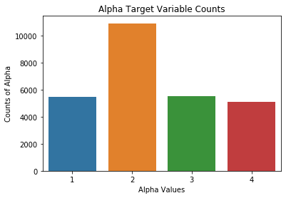

```python
# Bar plot for Alpha distribution
sns.countplot(csv_train_data.alpha)
plt.ylabel('Counts of Alpha')
plt.xlabel('Alpha Values')
plt.title('Alpha Target Variable Counts')
```

# Add new Feature Month

```python
csv_train_data['Month']=csv_train_data.date.dt.month
```

```python
csv_train_data.head()
```

|  | Id | date | ticker | SF1 | SF2 | SF3 | SF4 | SF5 | SF6 | SF7 | alpha | Month |
| --- | --- | --- | --- | --- | --- | --- | --- | --- | --- | --- | --- | --- |
| 0 | 1 | 2018-08-21 | $NTAP | -0.628652 | 0.988891 | -0.055714 | 0.774379 | 0.551089 | -1.329229 | -0.995539 | 2 | 8 |
| 1 | 2 | 2018-11-10 | $WYNN | 1.315786 | 1.438754 | 0.187327 | 0.608933 | -1.153030 | 1.859441 | 0.730995 | 3 | 11 |
| 2 | 3 | 2018-08-21 | $DRI | -1.141388 | -1.455016 | 0.332755 | 0.674502 | 0.111326 | -0.478597 | -1.488157 | 1 | 8 |
| 3 | 4 | 2018-10-07 | $GE | -0.054839 | -1.454149 | -0.162267 | -0.681870 | 0.307869 | -0.529987 | 0.404172 | 2 | 10 |
| 4 | 5 | 2018-12-09 | $FE | -0.686366 | 0.838865 | 0.073830 | 0.679024 | 0.329463 | 1.262782 | -1.024042 | 2 | 12 |

```python
# Visualize mean alpha value for every month for each ticker
plt.figure(figsize=(50,15))
csv_train_data.groupby(['Month','ticker'])['alpha'].mean().unstack().plot(kind='line')
plt.show()
```

[figure not shown]

```python
# Visualize how alpha value varies month wise
```

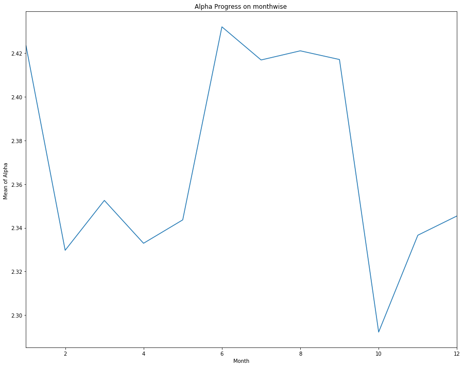

```python
plt.figure(figsize=(15,12))
csv_train_data.groupby('Month')['alpha'].mean().plot(kind='line')
plt.ylabel('Mean of Alpha ')
plt.xlabel('Month')
plt.title('Alpha Progress on monthwise ')
plt.show()
```

```python
# Write_input csv
csv_train_data.to_csv("Final_input.csv")
```

## Read Json File

```python
Json_train_data=pd.read_json("train_data-1573118738755.json")
```

# Convert Json to Panda dataframe

```python
Json_train_data = pd.DataFrame.from_dict(json_normalize(Json_train_data.records), orient='columns')
```

# See 1'st 10 row of record

# Json file has sentiment_score,stocktwit_tweet,ticker,timestamp features

# sentiment_score is Targte Variable

# Json file has 1039131 records

# In timestamp we need only date so need to update the timestamp column to extract date

# Check how many unique tickers are avaible in Json data and observe how much differ from train_factor csv file

```python
# See 1'st 10 row of record
Json_train_data.head(10)
```

|  | sentiment_score | stocktwit_tweet | ticker | timestamp |
| --- | --- | --- | --- | --- |
| 0 | 3 | $AMD going up but hesitating however chart is ... | $AMD | 2018-09-19 18:38:28+00:00 |
| 1 | 3 | @inforlong @MariaGascon Despite\nChina trade w... | $CAT | 2018-10-09 03:51:06+00:00 |
| 2 | 2 | $AVGO WTF? | $AVGO | 2018-07-12 13:35:32+00:00 |
| 3 | 2 | $PH\n New Insider Filing On: \n MULLER KLAUS P... | $PH | 2018-07-19 03:32:50+00:00 |
| 4 | 3 | $FB if it bounces tommorrow do the right thing... | $FB | 2018-08-23 19:07:54+00:00 |
| 5 | 0 | $FB as usual......RED \nevery day. | $FB | 2018-08-02 11:40:49+00:00 |
| 6 | 2 | $AET UnitedHealth Group Goes Ex-Dividend Today... | $AET | 2018-09-07 15:01:06+00:00 |
| 7 | 4 | $NOC let&#39;s see when we can hit 310 | $NOC | 2018-09-12 20:48:40+00:00 |
| 8 | 2 | @InCyD3R @Ferrabi I bet you’re also the one sa... | $AMZN | 2018-10-28 01:19:27+00:00 |
| 9 | 2 | $AMD Pastor the Stooge | $AMD | 2018-08-17 13:35:00+00:00 |

```python
# Check Summary of all variable
Json_train_data.describe(include='all')
```

|  | sentiment_score | stocktwit_tweet | ticker | timestamp |
| --- | --- | --- | --- | --- |
| count | 1.039131e+06 | 1039131 | 1039131 | 1039131 |
| unique | NaN | 959608 | 2181 | 905458 |
| top | NaN | $AMD | $AMD | 2018-08-13 14:00:03+00:00 |
| freq | NaN | 2474 | 163675 | 65 |
| mean | 2.203079e+00 | NaN | NaN | NaN |
| std | 1.105371e+00 | NaN | NaN | NaN |
| min | 0.000000e+00 | NaN | NaN | NaN |
| 25% | 2.000000e+00 | NaN | NaN | NaN |
| 50% | 2.000000e+00 | NaN | NaN | NaN |
| 75% | 3.000000e+00 | NaN | NaN | NaN |
| max | 4.000000e+00 | NaN | NaN | NaN |

```python
# Check shape of Json train data
Json_train_data.shape
```

```
(1039131, 4)
```

```python
# Check features data types
Json_train_data.dtypes
```

```
sentiment_score     int64
stocktwit_tweet    object
ticker             object
timestamp          object
dtype: object
```

```python
# In timestamp we need only date so need to update the timestamp column to extract date
Json_train_data.timestamp = Json_train_data.timestamp.str.split(' ').str[0]
```

```python
# Converting the Timestamp to Pandas Datetime format
Json_train_data.timestamp = pd.to_datetime(Json_train_data.timestamp)
```

```python
# Verify that now Timestamp showing only date and its type changed to datetime
print(Json_train_data.dtypes)
Json_train_data.head()
```

```
sentiment_score             int64
stocktwit_tweet            object
ticker                     object
timestamp          datetime64[ns]
dtype: object
```

|  | sentiment_score | stocktwit_tweet | ticker | timestamp |
| --- | --- | --- | --- | --- |
| 0 | 3 | $AMD going up but hesitating however chart is ... | $AMD | 2018-09-19 |
| 1 | 3 | @inforlong @MariaGascon Despite\nChina trade w... | $CAT | 2018-10-09 |
| 2 | 2 | $AVGO WTF? | $AVGO | 2018-07-12 |
| 3 | 2 | $PH\n New Insider Filing On: \n MULLER KLAUS P... | $PH | 2018-07-19 |
| 4 | 3 | $FB if it bounces tommorrow do the right thing... | $FB | 2018-08-23 |

```python
# Same as CSV File, Tickers in Json are also starting with $$
# Renaming Tickets where it starts with $$ instead of $
Json_train_data.ticker = Json_train_data.ticker.apply(lambda x: x.replace("$$","$"))
# Convering the Lowercase Tickers to Upper case to be consistent or Pandas with treat them unique
Json_train_data.ticker = Json_train_data.ticker.str.upper()
Json_train_data.head()
```

|  | sentiment_score | stocktwit_tweet | ticker | timestamp |
| --- | --- | --- | --- | --- |
| 0 | 3 | $AMD going up but hesitating however chart is ... | $AMD | 2018-09-19 |
| 1 | 3 | @inforlong @MariaGascon Despite\nChina trade w... | $CAT | 2018-10-09 |
| 2 | 2 | $AVGO WTF? | $AVGO | 2018-07-12 |
| 3 | 2 | $PH\n New Insider Filing On: \n MULLER KLAUS P... | $PH | 2018-07-19 |
| 4 | 3 | $FB if it bounces tommorrow do the right thing... | $FB | 2018-08-23 |

```python
# Observation :- Compare to Train factor csv , Json train data has more ticker.
# Assumption:To reduce the Json dataset we can remove the records which are not useful to train Train factor data.
#(This assumption will take care during apply the machine /deep leaning algorithm while predicting the model)
len(Json_train_data.ticker.unique())
```

```
1530
```

## See sentiment_score Distribution in JSON file

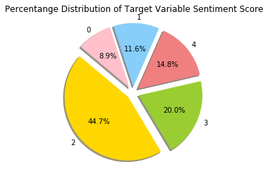

```python
score = Json_train_data.sentiment_score.value_counts()
# Data to plot piechart
colors = ['gold', 'yellowgreen', 'lightcoral', 'lightskyblue', 'pink']
explode = (0.1, 0.1, 0.1, 0.1, 0.1)  # explode 1st slice

# Plot
plt.pie(list(score.values), explode=explode, labels=list(score.keys()), colors=colors,
autopct='%1.1f%%', shadow=True, startangle=140)

plt.axis('equal')
plt.title('Percentange Distribution of Target Variable Sentiment Score')
plt.show()
```

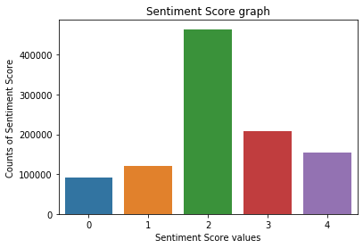

```python
# Bar plot for sentiment score distribution
sns.countplot(Json_train_data.sentiment_score)
plt.ylabel('Counts of Sentiment Score')
plt.xlabel('Sentiment Score values')
plt.title('Sentiment Score graph')
```